# Swire Coca-Cola Project EDA

Carson Hansen

2024-10-06

# 1 Data Prep

## 1.1 Load packages

```r
#load packages
library(tidyverse)
library(ggplot2)
```

#ERD Overview

```r
# Cost of Downtime Per Minute
((60000000/365)/6)/24/60
```

```
## [1] 19.02588
```

## 1.2 Load files

```r
# Load in the CSV files
data <- read.csv(file = "IWC Swire Data.csv")
```

## 1.3 Data Manipulation

```r
#Convert date data into date format and calculate the cost of maintenance
data <- data %>%
   mutate(EXECUTION_START_DATE = as.Date(EXECUTION_START_DATE, format = "%m/%d/%y")) %>%
   mutate(EXECUTION_FINISH_DATE = as.Date(EXECUTION_FINISH_DATE, format = "%m/%d/%y")) %>%
  mutate(DATE_DIFF_START_FINISH = EXECUTION_FINISH_DATE - EXECUTION_START_DATE) %>%
  mutate(EQUIP_START_UP_DATE = as.Date(EQUIP_START_UP_DATE, format = "%m/%d/%y")) %>%
  mutate(EQUIP_VALID_FROM = as.Date(EQUIP_VALID_FROM, format = "%m/%d/%y")) %>%
  mutate(EQUIP_VALID_TO = as.Date(EQUIP_VALID_TO, format = "%m/%d/%y")) %>%
  mutate(MACHINE_AGE_DAYS = EQUIP_VALID_TO - EQUIP_VALID_FROM) %>%
  mutate(COST_OF_MAINT_MIN = ACTUAL_WORK_IN_MINUTES * 19.03)
```

## 1.4 Data Summary

```r
#Data Summary
summary(data)
```

```
##     ORDER_ID           PLANT_ID         PRODUCTION_LOCATION
##  Min.   :1.000e+08   Length:1048575     Length:1048575
##  1st Qu.:4.021e+08   Class :character   Class :character
##  Median :7.045e+08   Mode  :character   Mode  :character
##  Mean   :4.604e+10
##  3rd Qu.:1.002e+09
##  Max.   :9.000e+11
##
##  EXECUTION_START_DATE EXECUTION_FINISH_DATE ACTUAL_START_TIME
##  Min.   :2013-08-19   Min.   :2016-07-25    Length:1048575
##  1st Qu.:2019-02-10   1st Qu.:2019-02-11    Class :character
##  Median :2020-12-10   Median :2020-12-11    Mode  :character
##  Mean   :2020-12-21   Mean   :2020-12-21
##  3rd Qu.:2022-12-08   3rd Qu.:2022-12-08
##  Max.   :2024-08-30   Max.   :2024-08-30
##
##  ACTUAL_FINISH_TIME ACTUAL_WORK_IN_MINUTES MAINTENANCE_PLAN   MAINTENANCE_ITEM
##  Length:1048575     Min.   :     0.0       Length:1048575     Min.   : 39801
##  Class :character   1st Qu.:    11.0       Class :character   1st Qu.: 41082
##  Mode  :character   Median :    48.0       Mode  :character   Median :113106
##                     Mean   :    89.5                          Mean   :117114
##                     3rd Qu.:    90.0                          3rd Qu.:134749
##                     Max.   :330184.8                          Max.   :346352
##                                                               NA's   :942794
##  MAINTENANCE_ACTIVITY_TYPE ORDER_DESCRIPTION  MAINTENANCE_TYPE_DESCRIPTION
##  Length:1048575            Length:1048575     Length:1048575
##  Class :character          Class :character   Class :character
##  Mode  :character          Mode  :character   Mode  :character
##
##
##
##
##  FUNCTIONAL_LOC     FUNCTIONAL_AREA_NODE_1_MODIFIED
##  Length:1048575     Length:1048575
##  Class :character   Class :character
##  Mode  :character   Mode  :character
##
##
##
##
```

[output cut: 25 more lines]

```
##  Min.   :2017-02-15   Min.   :1999-12-31   Length:1048575
##  1st Qu.:2017-02-15   1st Qu.:1999-12-31   Class :difftime
##  Median :2017-10-30   Median :1999-12-31   Mode  :numeric
##  Mean   :2019-05-31   Mean   :1999-12-31
##  3rd Qu.:2021-04-28   3rd Qu.:1999-12-31
##  Max.   :2024-05-20   Max.   :1999-12-31
##  NA's   :995325       NA's   :995325
##  MACHINE_AGE_DAYS  COST_OF_MAINT_MIN
##  Length:1048575    Min.   :      0
##  Class :difftime   1st Qu.:    209
##  Mode  :numeric    Median :    913
##                    Mean   :   1702
##                    3rd Qu.:   1713
##                    Max.   :6283417
##
```

```r
#Count of NA Values
data_summary <- data %>%
  summarise(across(everything(), ~ sum(is.na(.) | . == "")))
# Review Summary of NA
data_summary
```

```
##   ORDER_ID PLANT_ID PRODUCTION_LOCATION EXECUTION_START_DATE
## 1        0        0                   0                   NA
##   EXECUTION_FINISH_DATE ACTUAL_START_TIME ACTUAL_FINISH_TIME
## 1                    NA                 0                  0
##   ACTUAL_WORK_IN_MINUTES MAINTENANCE_PLAN MAINTENANCE_ITEM
## 1                      0           942794           942794
##   MAINTENANCE_ACTIVITY_TYPE ORDER_DESCRIPTION MAINTENANCE_TYPE_DESCRIPTION
## 1                         0            842365                       842344
##   FUNCTIONAL_LOC FUNCTIONAL_AREA_NODE_1_MODIFIED
## 1         842356                          843689
##   FUNCTIONAL_AREA_NODE_2_MODIFIED FUNCTIONAL_AREA_NODE_3_MODIFIED
## 1                          849224                          866487
##   FUNCTIONAL_AREA_NODE_4_MODIFIED FUNCTIONAL_AREA_NODE_5_MODIFIED EQUIPMENT_ID
## 1                          881222                         1047120       842344
##   EQUIPMENT_DESC EQUIP_CAT_DESC EQUIP_START_UP_DATE EQUIP_VALID_FROM
## 1         995325         995325                  NA               NA
##   EQUIP_VALID_TO DATE_DIFF_START_FINISH MACHINE_AGE_DAYS COST_OF_MAINT_MIN
## 1             NA                      0           995325                 0
```

```r
#Only show columns with numbers
data_summary %>%
  select(where(~ any(. != 0 & !is.na(.))))
```

```
##   MAINTENANCE_PLAN MAINTENANCE_ITEM ORDER_DESCRIPTION
## 1           942794           942794            842365
##   MAINTENANCE_TYPE_DESCRIPTION FUNCTIONAL_LOC FUNCTIONAL_AREA_NODE_1_MODIFIED
## 1                       842344         842356                          843689
##   FUNCTIONAL_AREA_NODE_2_MODIFIED FUNCTIONAL_AREA_NODE_3_MODIFIED
## 1                          849224                          866487
##   FUNCTIONAL_AREA_NODE_4_MODIFIED FUNCTIONAL_AREA_NODE_5_MODIFIED EQUIPMENT_ID
## 1                          881222                         1047120       842344
##   EQUIPMENT_DESC EQUIP_CAT_DESC MACHINE_AGE_DAYS
## 1         995325         995325           995325
```

# 2 Introduction

Swire Coca-Cola produces and packages bottled coke productions and then distributes them through the western United States. During production malfunctions and maintenance on various machines takes place. Some maintenance is planned, some is un planned.The data set provided contains a variety of inform about this maintenance. Accurately predicting when a piece of machinery will break will better enable the Swire team to plan and maintain the machines with greater efficiency. Swire estimates that there is a loss of roughly $60,000,000 per year in production downtime.

The purpose of this notebook is to explore this dataset and find correlations to assist with predicting when machines will faile. Questions we will look to answer will be, “What products fail most often?”, “How often do products fail?”,“What is the average live span of machines parts?”, “What patterns do we find in products that whwere not expected to break?”, “What facilities have the highest rate of unplanned part failutes?”, and more.

# 3 Data Description

The data set contains 1,048,575 rows of data with 25 variables/columns. Most variables are strings or categorical. Some data are IDs like, ORDER_ID, PLANT_ID, and EQUIPMENT_ID. Some data is numerical, like Actual_WORK_IN_MINUTES. 5 columns contain date data EXECUTION_START_TIME, EXECUTION_FINISH_TIME, EQUIP_START_UP_DATE, QUIP_VALID_FROM, AND EQUIP_VALID_TO. Additional columns will be added of calculations for dates, times, and cost.

# 4 Missing Data

Some variables are conditional on other values. For example, the MAINTENANCE_ACTIVITY_TYPE tracks if a maintenance was planned or unplanned. If it is planned columns like MAINTINANCE_PLAN and MAINTENANCE_ITEM. Meaning, certain columns will have larger NA or blank values. Values for each column of missing data can be found in the above table.

# 5 Data Exploration and Visualization

## 5.1 Summary Statistics

```r
#Create summary statistics of minutes worked by location and activity type.
data_stats <- data %>% group_by(PRODUCTION_LOCATION, MAINTENANCE_ACTIVITY_TYPE) %>% summarize(count = n(), prct_obs = ((n() / 1048575)*100) , avg_time = mean(ACTUAL_WORK_IN_MINUTES), st_dev = sd(ACTUAL_WORK_IN_MINUTES), min = min(ACTUAL_WORK_IN_MINUTES), max = max(ACTUAL_WORK_IN_MINUTES))
data_stats
```

```
## # A tibble: 12 × 8
## # Groups:   PRODUCTION_LOCATION [6]
##    PRODUCTION_LOCATION MAINTENANCE_ACTIVITY_TYPE  count prct_obs avg_time st_dev
##    <chr>               <chr>                      <int>    <dbl>    <dbl>  <dbl>
##  1 COTA                Planned                    19205    1.83      66.0   79.4
##  2 COTA                Unplanned                  67286    6.42      59.2  110.
##  3 MONACO              Planned                     6023    0.574     61.0  150.
##  4 MONACO              Unplanned                  56406    5.38      65.8  271.
##  5 MONZA               Planned                    31429    3.00      39.0   60.1
##  6 MONZA               Unplanned                 129996   12.4      110.  1101.
##  7 ROMA                Planned                    14748    1.41      40.9  122.
##  8 ROMA                Unplanned                  42035    4.01      51.5  151.
##  9 SILVERSTONE         Planned                    20018    1.91      49.1  126.
## 10 SILVERSTONE         Unplanned                 446852   42.6       97.9 1194.
## 11 SUZUKA              Planned                    13035    1.24      49.9   94.3
## 12 SUZUKA              Unplanned                 201542   19.2      103.   288.
## # ℹ 2 more variables: min <dbl>, max <dbl>
```

## 5.2 Cost of Maintinance

```r
#Average revenue lost of production downtime per hour/Minute per plant
# 60000000 lost revenue from production lost per year
# 365 days per year
# 6 facilities
# 24 hours per day
# Cost per hour per facility
(((60000000/365)/6)/24)
```

```
## [1] 1141.553
```

```r
# Per Minute
(((60000000/365)/6)/24)/60
```

```
## [1] 19.02588
```

With roughly 60,000,000 lost per year in production losses due to maintenance, we can see that the average cost per hour per production facility, when the lines are not in production is roughly 1,141.55 per hour and 19.03 per minute. Therefore, time spent on machines not being utilized is extremely costly.

```r
#Average Time to fix by maintenance type
data %>% group_by(MAINTENANCE_ACTIVITY_TYPE) %>%  summarise(avg = mean(ACTUAL_WORK_IN_MINUTES))
```

```
## # A tibble: 2 × 2
##   MAINTENANCE_ACTIVITY_TYPE   avg
##   <chr>                     <dbl>
## 1 Planned                    48.8
## 2 Unplanned                  94.0
```

```r
data %>% group_by(MAINTENANCE_ACTIVITY_TYPE) %>% summarize(n = n(), prct = (n()/1048575))
```

```
## # A tibble: 2 × 3
##   MAINTENANCE_ACTIVITY_TYPE      n   prct
##   <chr>                      <int>  <dbl>
## 1 Planned                   104458 0.0996
## 2 Unplanned                 944117 0.900
```

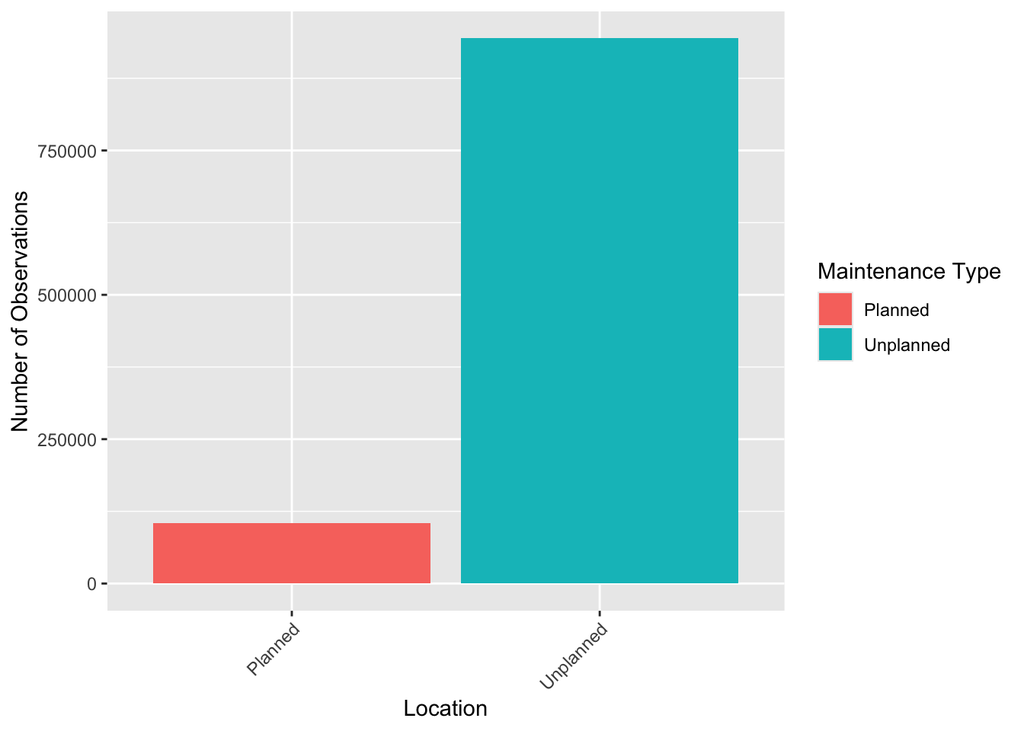

```r
# Distribution of observations by facility by maintinance type
data %>% ggplot(aes(x = MAINTENANCE_ACTIVITY_TYPE, fill = MAINTENANCE_ACTIVITY_TYPE)) +
  geom_bar(position = "dodge") +
  theme(axis.text.x = element_text(angle = 45, hjust = 1)) +
  ylab("Number of Observations") +
  xlab("Location") +
  labs(fill = 'Maintenance Type')
```

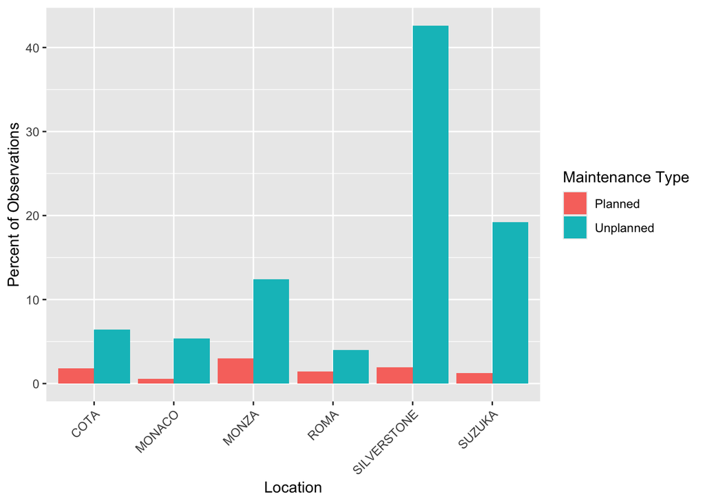

```r
# Distribution of observations by facility by maintenance type
data_stats %>% ggplot(aes(x = PRODUCTION_LOCATION, y = prct_obs, fill = MAINTENANCE_ACTIVITY_TYPE)) +
  geom_col(position = "dodge") +
  theme(axis.text.x = element_text(angle = 45, hjust = 1)) +
  ylab("Percent of Observations") +
  xlab("Location") +
  labs(fill = 'Maintenance Type')
```

We see that there is a large skew of observations to the Silverstone and Suzuka plants. Just with Silverstone unplanned it is 42.62% of all records. Suzuka unplanned maintenance is also high with 19.22 records. These two combined contain almost 2 out of every 3 rows in the data.

## 5.3 Bar Plot 1

```r
# Create a table of the data
data2 <- data %>% group_by(PRODUCTION_LOCATION, MAINTENANCE_ACTIVITY_TYPE) %>% summarize(count = n(), avg_time = mean(ACTUAL_WORK_IN_MINUTES))
```

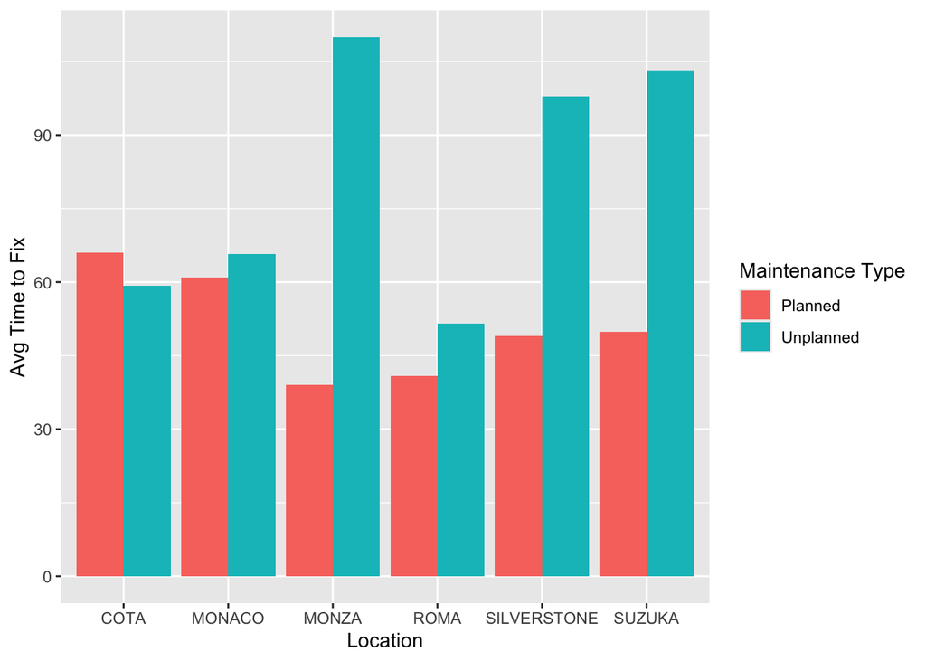

```r
# Breakdown of average time to fix by location by type
data2 %>% ggplot(mapping = aes(x = PRODUCTION_LOCATION, y = avg_time, fill = MAINTENANCE_ACTIVITY_TYPE)) +
  geom_col(position = "dodge") +
  labs(fill = 'Maintenance Type') +
  xlab('Location') +
  ylab('Avg Time to Fix') +
  labs(color = 'Maintenance Type')
```

We can see that there is a large disparity between the average fix time by maintenance type at the Monza, Silverstone, and Suzuka plants. Cota, Monaco, and Roma have closer times. Cota, is also the only location where the average fix time for unplanned maintenance is quicker than planned.

## 5.4 Bar Plot 2

```r
# Create a Table
data1 <- data %>% group_by(FUNCTIONAL_AREA_NODE_1_MODIFIED, MAINTENANCE_ACTIVITY_TYPE) %>% summarize(count = n(), avg_time = mean(ACTUAL_WORK_IN_MINUTES))
data1
```

```
## # A tibble: 15 × 4
## # Groups:   FUNCTIONAL_AREA_NODE_1_MODIFIED [8]
##    FUNCTIONAL_AREA_NODE_1_MODIFIED MAINTENANCE_ACTIVITY_TYPE  count avg_time
##    <chr>                           <chr>                      <int>    <dbl>
##  1 ""                              Planned                      925     50.5
##  2 ""                              Unplanned                 842764     89.3
##  3 "COOLER SERVICE"                Planned                     1928     40.3
##  4 "COOLER SERVICE"                Unplanned                      1    360
##  5 "COTA PRODUCTION"               Planned                    19205     66.0
##  6 "COTA PRODUCTION"               Unplanned                  32951     93.7
##  7 "FLEET"                         Unplanned                     93    110.
##  8 "MONZA PRODUCTION"              Planned                    30728     38.8
##  9 "MONZA PRODUCTION"              Unplanned                   5878    171.
## 10 "PRODUCTION"                    Planned                    20553     46.6
## 11 "PRODUCTION"                    Unplanned                  22087    150.
## 12 "SILVERSTONE PRODUCTION"        Planned                    20012     49.0
## 13 "SILVERSTONE PRODUCTION"        Unplanned                  25095    155.
## 14 "SUZUKA PRODUCTION"             Planned                    11107     51.5
## 15 "SUZUKA PRODUCTION"             Unplanned                  15248    141.
```

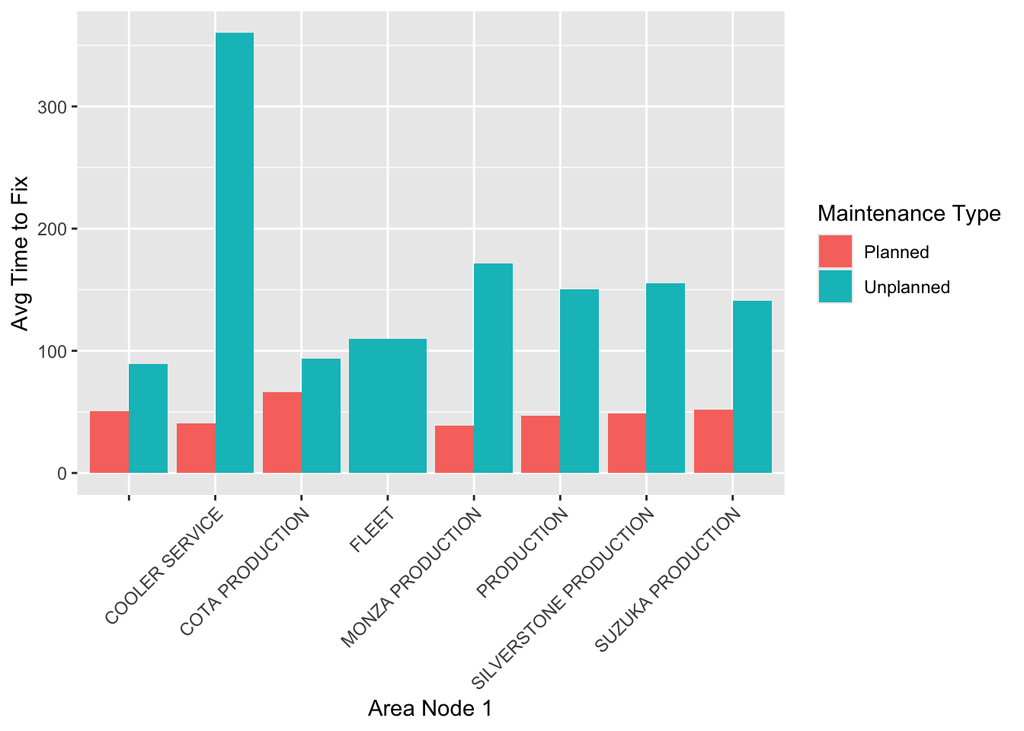

```r
# Breakdown of average time to fix by location by type
data1 %>% ggplot(mapping = aes(x = FUNCTIONAL_AREA_NODE_1_MODIFIED, y = avg_time, fill = MAINTENANCE_ACTIVITY_TYPE)) +
  geom_col(position = "dodge") +
  labs(fill = 'Maintenance Type') +
  xlab('Area Node 1') +
  ylab('Avg Time to Fix') +
  theme(axis.text.x = element_text(angle = 45, hjust = 1))
```

When looking at the area of maintenance, we see that Cooler Service has on average a high time to fix. However, there is only one observation indicating low occurrence. Monza Production has a high unplanned fix time with almost 6,000 occurrences. Everything fleet related was unplanned.

## 5.5 Bar Plot 3

```r
# Create a Table
data3 <- data %>% group_by(FUNCTIONAL_AREA_NODE_5_MODIFIED, MAINTENANCE_ACTIVITY_TYPE) %>% summarize(count = n(), avg_time = mean(ACTUAL_WORK_IN_MINUTES))
data3
```

```
## # A tibble: 53 × 4
## # Groups:   FUNCTIONAL_AREA_NODE_5_MODIFIED [36]
##    FUNCTIONAL_AREA_NODE_5_MODIFIED  MAINTENANCE_ACTIVITY_TYPE  count avg_time
##    <chr>                            <chr>                      <int>    <dbl>
##  1 ""                               Planned                   104130     48.6
##  2 ""                               Unplanned                 942990     93.8
##  3 "*OLD SYSTEM MT CASE CONVEYORS*" Planned                       13    157.
##  4 "*OLD SYSTEM MT CASE CONVEYORS*" Unplanned                     25    243.
##  5 "ACCUMULATION TABLES"            Unplanned                     10     64.5
##  6 "BLOWER SECTION #1 ACE-3-M101"   Unplanned                      1     60
##  7 "BLOWER SECTION #11 ACE-3-M111"  Unplanned                      1    180
##  8 "BLOWER SECTION #12 ACE-3-M112"  Unplanned                      3    120
##  9 "COMPRESSOR"                     Planned                       18    283.
## 10 "COMPRESSOR"                     Unplanned                     63    463.
## # ℹ 43 more rows
```

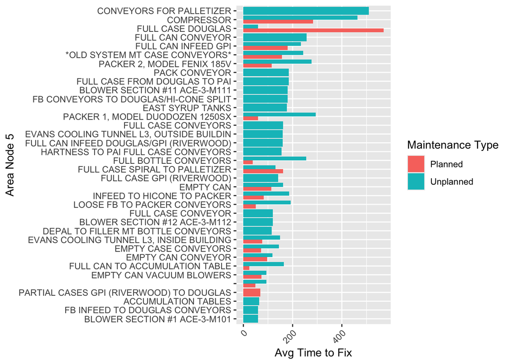

```r
# Breakdown of average time to fix Area Node 5 by type
data3 %>% ggplot(mapping = aes(x = reorder(FUNCTIONAL_AREA_NODE_5_MODIFIED, +avg_time), y = avg_time, fill = MAINTENANCE_ACTIVITY_TYPE)) +
  geom_col(position = "Dodge") +
  labs(fill = 'Maintenance Type') +
  coord_flip() +
  xlab('Area Node 5') +
  ylab('Avg Time to Fix') +
  theme(axis.text.x = element_text(angle = 45, hjust = 1))
```

## 5.6 Bar Plot 4

```r
# Create a Table
data4 <- data %>% group_by(EQUIP_CAT_DESC, MAINTENANCE_ACTIVITY_TYPE) %>% summarize(count = n(), avg_time = mean(ACTUAL_WORK_IN_MINUTES))
data4
```

```
## # A tibble: 10 × 4
## # Groups:   EQUIP_CAT_DESC [5]
##    EQUIP_CAT_DESC               MAINTENANCE_ACTIVITY_TYPE  count avg_time
##    <chr>                        <chr>                      <int>    <dbl>
##  1 ""                           Planned                    68615     51.3
##  2 ""                           Unplanned                 926710     93.2
##  3 "Machines"                   Planned                    35705     43.5
##  4 "Machines"                   Unplanned                  17365    133.
##  5 "Plant & Buildings"          Planned                       26     34.0
##  6 "Plant & Buildings"          Unplanned                     23    142.
##  7 "Production resources/tools" Planned                       72    280.
##  8 "Production resources/tools" Unplanned                      8     93
##  9 "Test/measurement equipment" Planned                       40     50.4
## 10 "Test/measurement equipment" Unplanned                     11     77.8
```

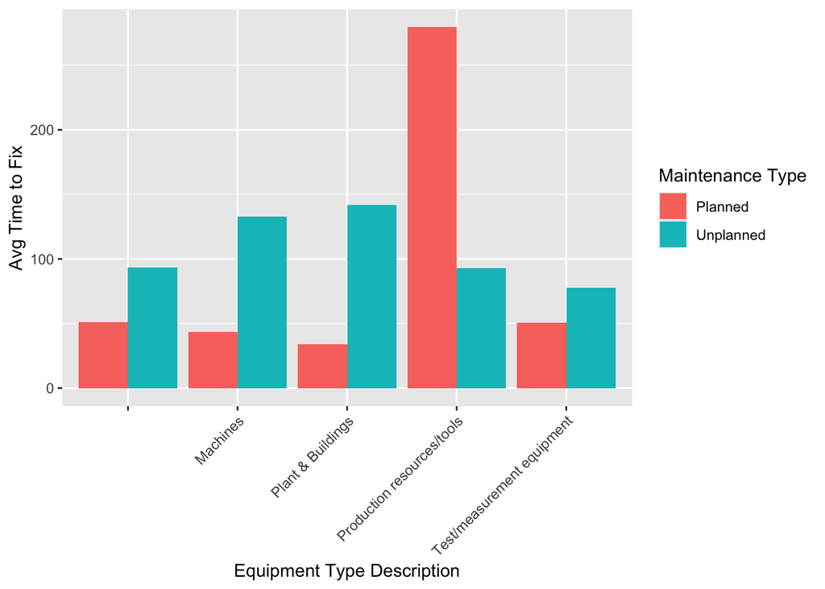

```r
# Breakdown of average time to fix Equipment Type by Maintinance Type
data4 %>% ggplot(mapping = aes(x = EQUIP_CAT_DESC, y = avg_time, fill = MAINTENANCE_ACTIVITY_TYPE)) +
  geom_col(position = "dodge") +
  labs(fill = 'Maintenance Type') +
  xlab('Equipment Type Description') +
  ylab('Avg Time to Fix') +
  theme(axis.text.x = element_text(angle = 45, hjust = 1))
```

As anticipated, most equipment, when planned are quicker to fix. However, production resources/tools is the outlier where planned takes longer to fix, and unplanned is significantly quicker (about 3 hours quicker to fix). Also, roughly 90% of the data is in the blank value column. Meaning most rows dont have this filled in.

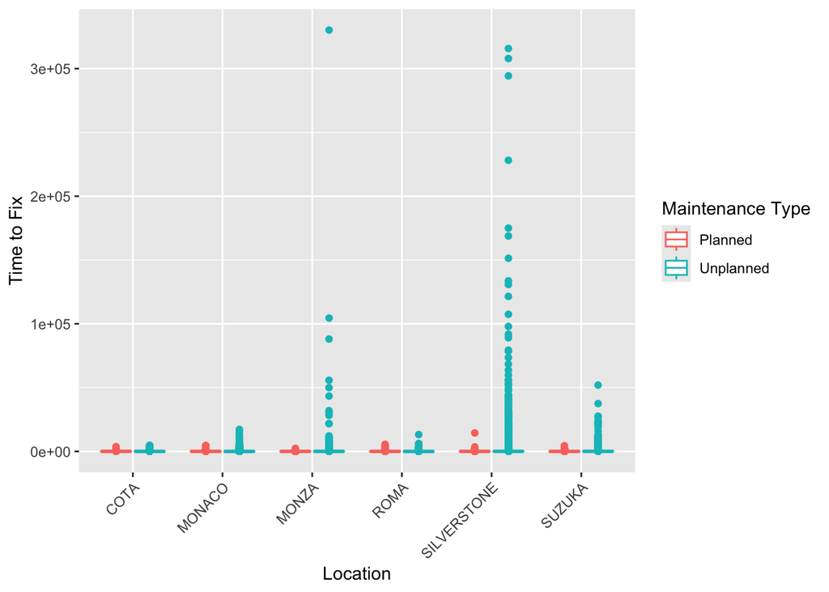

```r
#Histogram of production location by work in minutes by maintanence type
data %>% ggplot(aes(x = PRODUCTION_LOCATION, y = ACTUAL_WORK_IN_MINUTES, color = MAINTENANCE_ACTIVITY_TYPE)) +
  geom_boxplot() +
  theme(axis.text.x = element_text(angle = 45, hjust = 1)) +
  xlab('Location') +
  ylab('Time to Fix') +
  labs(color = 'Maintenance Type')
```

This chart illustrates a large disparity across fix times. Monza and Silverstone have a extreme outliers that affect the scale and chart. Cota, Monaco, Roma, and Suzuka appear to have more centralized observation values for actual work time in minutes.